# Concept of the package

Tobias Gauster, Cath Sefton

2017-08-30

generated with R version 3.4.1 (2017-06-30) and **smires** version 0.5

This document was created with package version `0.5`. Currently the following data sets are already included in the package:

```r
library(smires)
data(package = "smires")$results[, "Item"]
```

```
## [1] "ampneyBrook" "balder"      "cy1"         "cy2"         "cy3"
```

Let’s print the first observations of the river Balder at station Balderhead Reservoir:

```r
head(balder)
```

```
## # A tibble: 6 x 2
##         time discharge
##       <date>     <dbl>
## 1 1974-09-01         0
## 2 1974-09-02         0
## 3 1974-09-03         0
## 4 1974-09-04         0
## 5 1974-09-05         0
## 6 1974-09-06         0
```

For the time being, each time series of discharges is a `data.frame` with the first column being the time index (of class `Date`) and the second column being the discharge. In this particular data set the unit of discharge is m³/s.

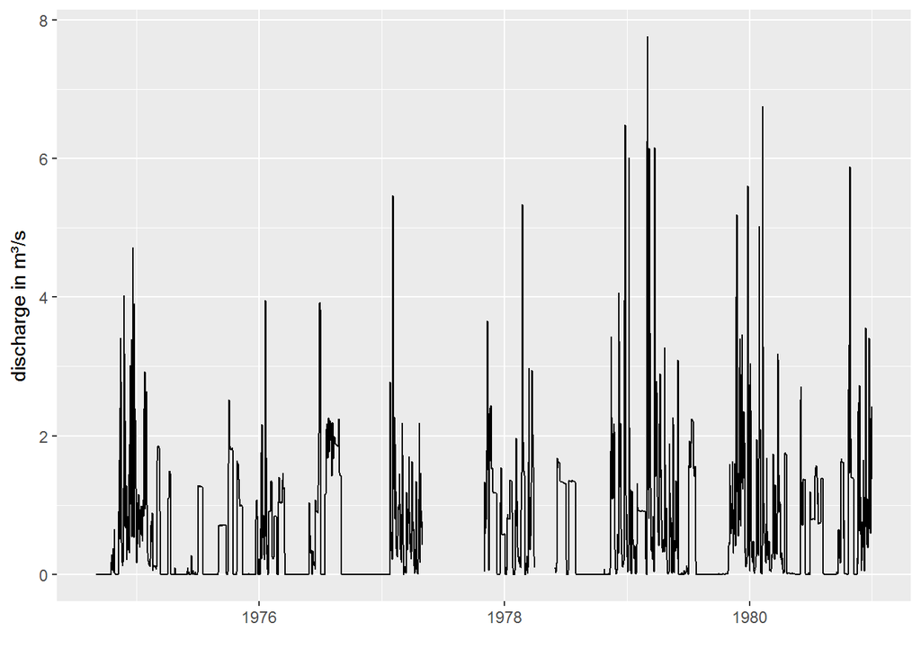

```r
library(ggplot2)
ggplot(balder, aes(time, discharge)) + geom_line() +
  labs(x = "", y = "discharge in m³/s")
```

A few checks are performed prior to the computation of indices.

- time indices are unique
- time series is regular (daily, weekly or monthly)
- proportion of missing values
- proportion of values below or equal the measurement accuracy

```r
balder <- validate(balder, accuracy = 0.005)
```

```
## The time series contains 23 observations equal to the measurement accuracy of '0.005' (1 %).
```

```
## The time series contains 762 observations below the measurement accuracy of '0.005' (32.9 %).
```

```
## The time series contains 654 observations equal to zero (28.3 %).
```

```
## The time series contains 245 missing observations (10.6 %).
```

```
## Time series covers only 6.3 years. A minimum length of 10 years is advised.
```

# 1 Units

For the time being only daily time series are supported. The default value of the threshold flow (0.001 m³/s) is only appropriate if your discharges are also in m³/s. If not, do not forget to choose a meaningful threshold.

# 2 Threshold

A day is attributed to `no-flow` if the observed discharge is **smaller or equal** to the threshold discharge. Given a threshold of 0 m³/s and an observed discharge of 0 m³/s, this day is classified as `no-flow`.

# 3 Time intervals

```
## # A tibble: 2 x 5
##   spell   state      onset termination duration
##   <ord>  <fctr>     <date>      <date>   <time>
## 1     1 no-flow 1974-09-01  1974-10-17  46 days
## 2     2    flow 1974-10-17  1974-10-30  13 days
```

A time interval like in the example above is constructed in a way that $duration = end - start$ implying that the end date is **not** part of the interval, it is a right opened interval: $[start,\ end)$.